# EEG_DataScience

Import all the necessary packages:

```python
import pandas as pd
import numpy as np
from os.path import join
import matplotlib.pyplot as plt
from scipy.fft import fft, fftfreq
```

Use Pandas to read the CSV file into a Pandas dataframe and use the dataframe to access the EEG files

```python
df = pd.read_csv ('train_info.csv')
if 0:
    print(f"\n# lines = {len(df)}\n")
    print("Columns:\n")
    print(df.columns)
    print("\n")
    print(df.info())
    print(df.describe())

print(df)
```

```
     file_id pt_id loc  sz_present                               sz_type  \
0   train_01   C20  LE           1          IC - Focal Evolving to BL TC
1   train_02   A12  LF           0                                   NaN
2   train_03    C6  RE           1         IB - Focal Impaired Awareness
3   train_04   C14  RE           0                                   NaN
4   train_05    A3  LF           0                                   NaN
5   train_06    A6  RF           1         IB - Focal Impaired Awareness
6   train_07    A6  LF           1         IB - Focal Impaired Awareness
7   train_08    B8  RF           0                                   NaN
8   train_09   A12  LE           0                                   NaN
9   train_10   A25  RE           1             IA1 - Focal Aware w/Motor
10  train_11   B17  LF           0                                   NaN
11  train_12   A25  RE           1             IA1 - Focal Aware w/Motor
12  train_13    B8  RF           0                                   NaN
13  train_14   A25  LF           1          IC - Focal Evolving to BL TC
```

[output cut: 20 more lines]

Get the metadata for the group of seizure-present files and the group of seizure-absent files from the dataframe:

```python
szIdx = df.index[df['sz_present'] == 1].tolist()
nonIdx = df.index[df['sz_present'] == 0].tolist()
sz = df.loc[df['sz_present']==1]
nonsz = df.loc[df['sz_present']==0]
print('Seizure-present files:')
print(sz)
print('\nSeizure-absent files:')
print(nonsz)
```

```
Seizure-present files:
     file_id pt_id loc  sz_present                               sz_type  \
0   train_01   C20  LE           1          IC - Focal Evolving to BL TC
2   train_03    C6  RE           1         IB - Focal Impaired Awareness
5   train_06    A6  RF           1         IB - Focal Impaired Awareness
6   train_07    A6  LF           1         IB - Focal Impaired Awareness
9   train_10   A25  RE           1             IA1 - Focal Aware w/Motor
11  train_12   A25  RE           1             IA1 - Focal Aware w/Motor
13  train_14   A25  LF           1          IC - Focal Evolving to BL TC
14  train_15   B32  LF           1  IIA1 - Generalized Absence - Typical

    t_start  t_end
0      77.0  155.0
2     303.0  431.0
5     354.0  463.0
```

[output cut: 16 more lines]

Read data for seizure-present EEGs from binary files as indicated in the metadata in the Pandas dataframe:

```python
dt = np.uint16
szData = np.zeros((8, 307200))
idx = 0
for s in szIdx:
    path = join('train_files', df['file_id'][s] + '.dat')
    print(path)
    infile = open(path, 'rb')
    temp = np.array([])
    while True:
        buf = infile.read(1024*1024)
        if buf:
            a = np.frombuffer(buf,dtype=dt)
            temp = np.append(temp, a, axis=0)
            print(f'.', end ='', flush = True)
        else:
            break
    infile.close()
    print(np.shape(temp))
    szData[idx][:] = temp
    idx += 1
print(np.shape(szData))
```

```
train_files\train_01.dat
.(307200,)
train_files\train_03.dat
.(307200,)
train_files\train_06.dat
.(307200,)
train_files\train_07.dat
.(307200,)
train_files\train_10.dat
.(307200,)
train_files\train_12.dat
.(307200,)
train_files\train_14.dat
.(307200,)
train_files\train_15.dat
.(307200,)
(8, 307200)
```

Read in seizure-absent EEGs from binary data files:

```python
nonszData = np.zeros((8, 307200))
idx = 0
for n in nonIdx:
    path = join('train_files', df['file_id'][n] + '.dat')
    print(path)
    infile = open(path, 'rb')
    temp = np.array([])
    while True:
        buf = infile.read(1024*1024)
        if buf:
            a = np.frombuffer(buf,dtype=dt)
            temp = np.append(temp, a, axis=0)
            print(f'.', end ='', flush = True)
        else:
            break
    infile.close()
    print(np.shape(temp))
    nonszData[idx][:] = temp
    idx += 1
print(np.shape(nonszData))
```

```
train_files\train_02.dat
.(307200,)
train_files\train_04.dat
.(307200,)
train_files\train_05.dat
.(307200,)
train_files\train_08.dat
.(307200,)
train_files\train_09.dat
.(307200,)
train_files\train_11.dat
.(307200,)
train_files\train_13.dat
.(307200,)
train_files\train_16.dat
.(307200,)
(8, 307200)
```

Convert the EEGs from quantized unsigned ints to microvolts:

```python
szData_uv = szData*(175*2)/65535 - 175
nonszData_uv = nonszData*(175*2)/65535 - 175
print(np.max(szData_uv))
print(np.min(szData_uv))
print(np.max(nonszData_uv))
print(np.min(nonszData_uv))
```

```
174.658197909514
-175.0
174.658197909514
-175.0
```

Specify the signal processing parameters:

```python
fs = 512 # Hz
T = 1/fs # seconds

# time axis
t = np.arange(np.size(szData_uv,1))/fs
```

Plot full EEGs that contain seizures:

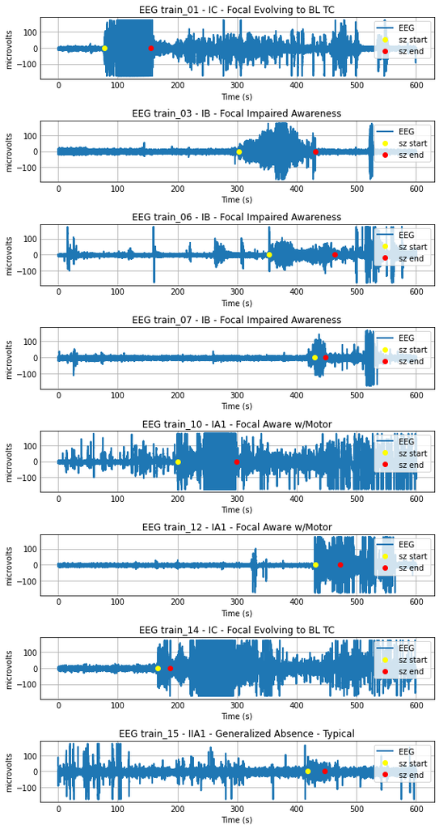

```python
plt.style.use('_mpl-gallery')
fig, ax = plt.subplots(np.size(szData_uv,0),1,figsize=(8, 15))
cnt = 0
for s in szIdx:
    x = t
    y = szData_uv[cnt][:]

    t_start = df['t_start'][s]
    t_end = df['t_end'][s]

    # plot
    ax[cnt].plot(x, y, linewidth=2.0, label='EEG')
    ax[cnt].plot(t_start, 0, "o", linewidth=2.0, color="yellow", label='sz start')
    ax[cnt].plot(t_end, 0, "o", linewidth=2.0, color="red", label='sz end')
    ax[cnt].grid(True)
    ax[cnt].set_xlabel('Time (s)')
    ax[cnt].set_ylabel('microvolts')
    ax[cnt].set_title('EEG ' + df['file_id'][s] + ' - ' + df['sz_type'][s])
    ax[cnt].legend(loc='upper right')
    cnt += 1
fig.tight_layout()
plt.show()
```

Three components can be observed: the seizures, between the yellow and red dots, the pre-ictal period, and the post-ictal period. The activity in the post-ictal period is generally greater than the activity during the pre-ictal period. Note that seizures have different durations. Five of the recordings (train sets 01, 03, 10. 12 and 14) have amplitude clipping due to dynamic range saturation. The clipping precludes waveform analysis with those recordings.

Extract the actual seizure activity each of the full recordings and plot them

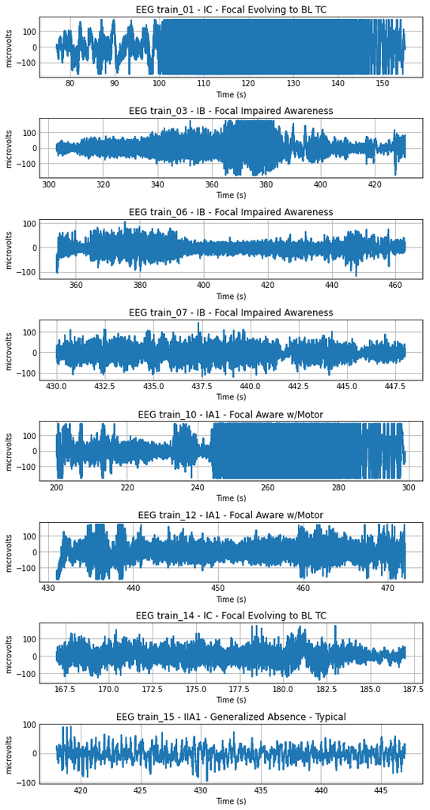

```python
plt.style.use('_mpl-gallery')
fig, ax = plt.subplots(np.size(szData_uv,0),1,figsize=(8, 15))
t_start_sample = [None] * np.size(szData_uv,0)
t_stop_sample = [None] * np.size(szData_uv,0)
cnt = 0
for s in szIdx:
    t_start = df['t_start'][s]
    t_end = df['t_end'][s]
    t_start_sample[cnt] = int(np.floor(t_start*fs))
    t_stop_sample[cnt] = int(np.ceil(t_end*fs))
    x = t[t_start_sample[cnt]:t_stop_sample[cnt]]
    y = szData_uv[cnt][t_start_sample[cnt]:t_stop_sample[cnt]]

    # plot
    ax[cnt].plot(x, y, linewidth=2.0)
    ax[cnt].grid(True)
    ax[cnt].set_xlabel('Time (s)')
    ax[cnt].set_ylabel('microvolts')
    ax[cnt].set_title('EEG ' + df['file_id'][s] + ' - ' + df['sz_type'][s])
    cnt += 1
fig.tight_layout()
plt.show()
```

Plot the full EEGs that do not contain seizures:

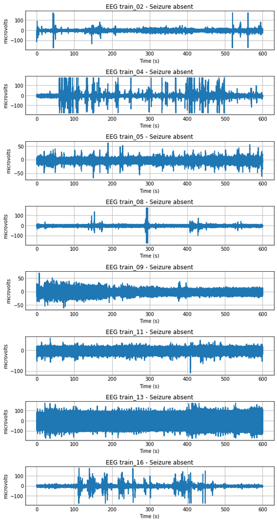

```python
plt.style.use('_mpl-gallery')
fig, ax = plt.subplots(np.size(nonszData_uv,0),1,figsize=(8, 15))
cnt = 0
for n in nonIdx:
    x = t
    y = nonszData_uv[cnt][:]

    # plot
    ax[cnt].plot(x, y, linewidth=2.0)
    ax[cnt].grid(True)
    ax[cnt].set_xlabel('Time (s)')
    ax[cnt].set_ylabel('microvolts')
    ax[cnt].set_title('EEG ' + df['file_id'][n] + ' - Seizure absent')
    cnt += 1
fig.tight_layout()
plt.show()
```

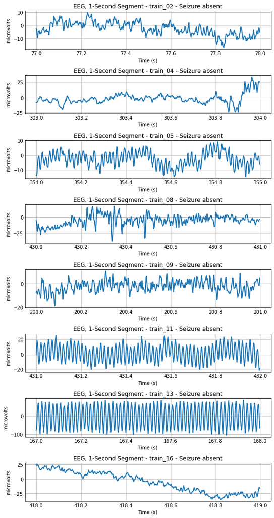

```python
plt.style.use('_mpl-gallery')
fig, ax = plt.subplots(np.size(nonszData_uv,0),1,figsize=(8, 15))
cnt = 0
for n in nonIdx:
    x = t[t_start_sample[cnt]: (t_start_sample[cnt] + fs*1)]
    y = nonszData_uv[cnt][t_start_sample[cnt]:(t_start_sample[cnt] + fs*1)]

    # plot
    ax[cnt].plot(x, y, linewidth=2.0)
    ax[cnt].grid(True)
    ax[cnt].set_xlabel('Time (s)')
    ax[cnt].set_ylabel('microvolts')
    ax[cnt].set_title('EEG, 1-Second Segment - ' + df['file_id'][n] + ' - Seizure absent')
    cnt += 1
fig.tight_layout()
plt.show()
```

The question is how the seizure EEG recordings compare to these apparantly "normal" EEG recordings. The train_11 and train_13 EEG recordings look too regular to be biological phenomena. One suspects that they may be recordings of electronics, like the lights or a component with the EEG sensor itself. In fact, it is mostly likely the lights at 60 Hz. The PSDs of the seizure-absent data have spikes at 60 Hz. One could use a notch filter to remove it.

Plot the first second (512 samples) of the seizures to see the seizure recordings in higher time resolution to try to see a waveform:

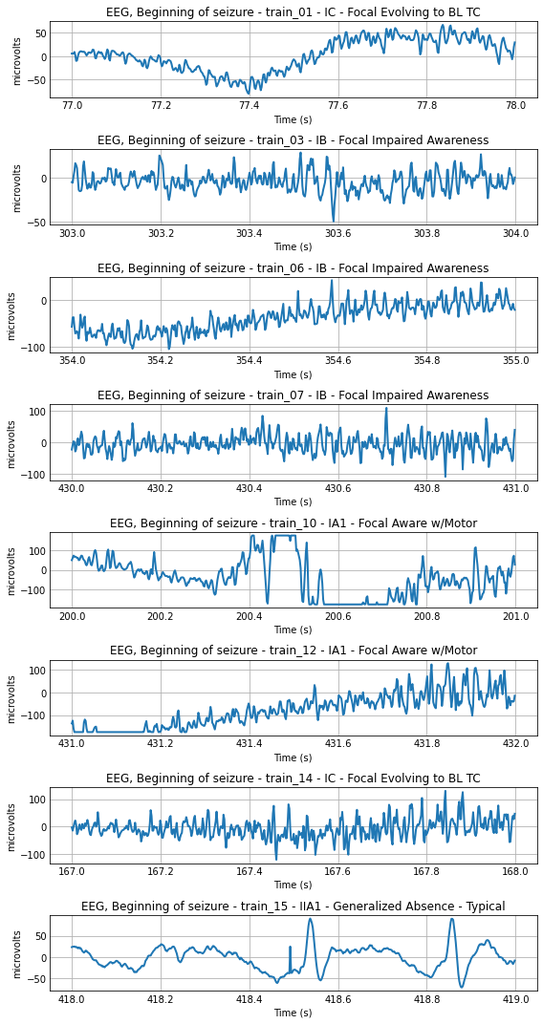

```python
plt.style.use('_mpl-gallery')
fig, ax = plt.subplots(np.size(szData_uv,0),1,figsize=(8, 15))
cnt = 0
for s in szIdx:
    x = t[t_start_sample[cnt]:t_start_sample[cnt] + fs*1]
    y = szData_uv[cnt][t_start_sample[cnt]:t_start_sample[cnt] + fs*1]

    # plot
    ax[cnt].plot(x, y, linewidth=2.0)
    ax[cnt].grid(True)
    ax[cnt].set_xlabel('Time (s)')
    ax[cnt].set_ylabel('microvolts')
    ax[cnt].set_title('EEG, Beginning of seizure - ' + df['file_id'][s] + ' - ' + df['sz_type'][s])
    cnt += 1
fig.tight_layout()
plt.show()
```

The Generalized Absence seizure (Train_15) has the most characteristic pattern that jumps out right away. There are periodic spikes at a certain frequency that can be characterized.

Extend the plot to the first 2 seconds (1024 samples) of the seizures to see the seizure recordings in higher time resolution to try to see a waveform:

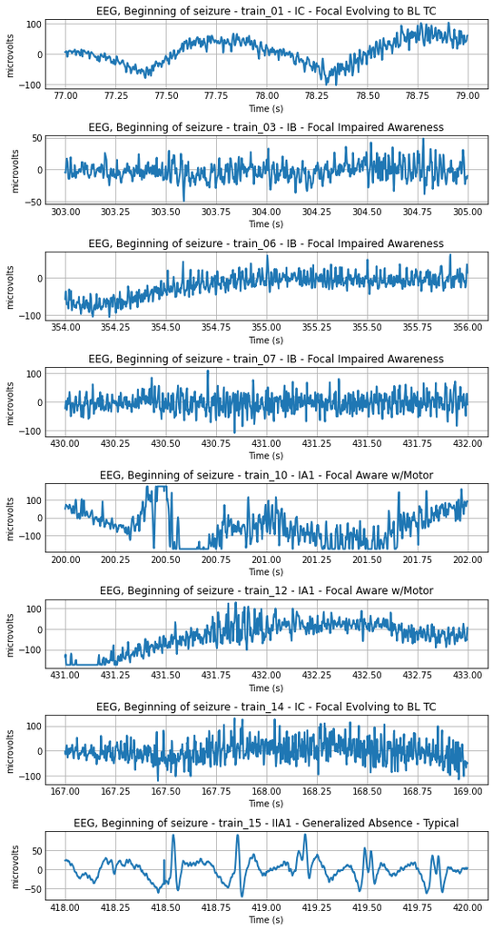

```python
plt.style.use('_mpl-gallery')
fig, ax = plt.subplots(np.size(szData_uv,0),1,figsize=(8, 15))
cnt = 0
for s in szIdx:
    x = t[t_start_sample[cnt]:t_start_sample[cnt] + fs*2]
    y = szData_uv[cnt][t_start_sample[cnt]:t_start_sample[cnt] + fs*2]

    # plot
    ax[cnt].plot(x, y, linewidth=2.0)
    ax[cnt].grid(True)
    ax[cnt].set_xlabel('Time (s)')
    ax[cnt].set_ylabel('microvolts')
    ax[cnt].set_title('EEG, Beginning of seizure - ' + df['file_id'][s] + ' - ' + df['sz_type'][s])
    cnt += 1
fig.tight_layout()
plt.show()
```

The Generalized Absence seizure (Train_15) has the most characteristic pattern that jumps out right away. There are periodic spikes (even double spikes) that occur at a certain frequency that can be characterized.

Plot 1 second during the middle of each seizure:

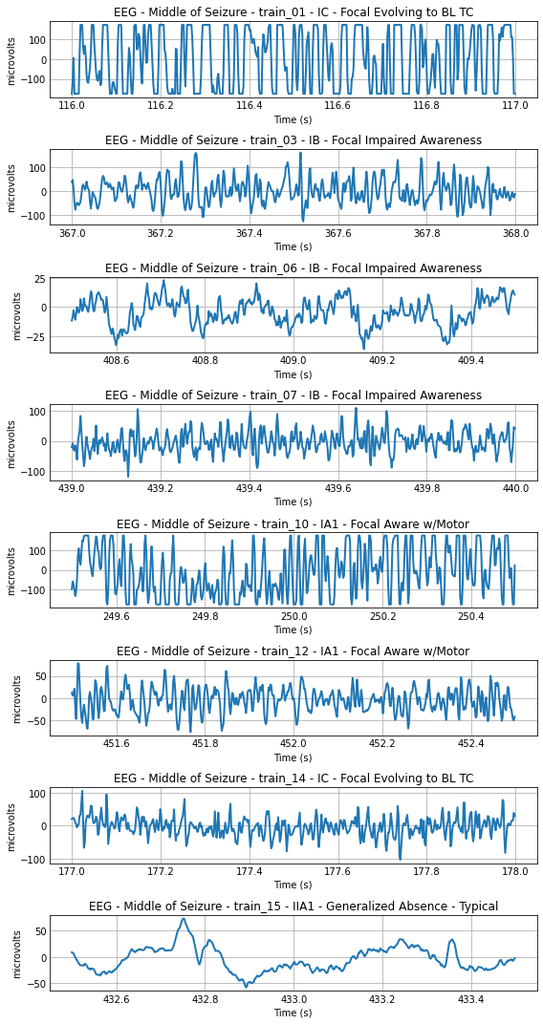

```python
plt.style.use('_mpl-gallery')
fig, ax = plt.subplots(np.size(szData_uv,0),1,figsize=(8, 15))
cnt = 0
for s in szIdx:
    duration = df['t_end'][s]- df['t_start'][s]
    x = t[t_start_sample[cnt] + int((duration/2)*fs) :t_start_sample[cnt] + int((duration/2)*fs) + fs*1]
    y = szData_uv[cnt][t_start_sample[cnt] + int((duration/2)*fs) :t_start_sample[cnt] + int((duration/2)*fs) + fs*1]

    # plot
    ax[cnt].plot(x, y, linewidth=2.0)
    ax[cnt].grid(True)
    ax[cnt].set_xlabel('Time (s)')
    ax[cnt].set_ylabel('microvolts')
    ax[cnt].set_title('EEG - Middle of Seizure - ' + df['file_id'][s] + ' - ' + df['sz_type'][s])
    cnt += 1
fig.tight_layout()
plt.show()
```

Plot 1 second just before the end of each seizure:

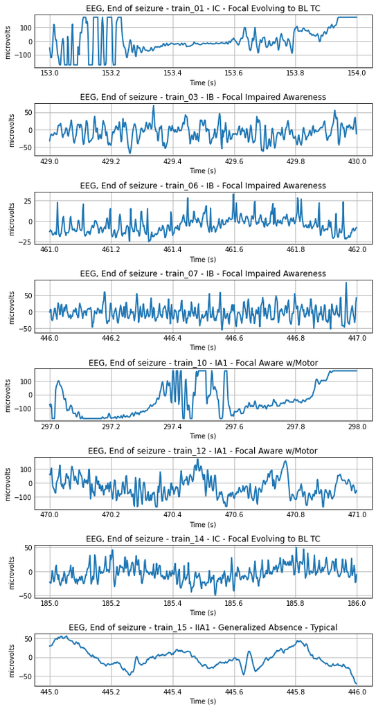

```python
plt.style.use('_mpl-gallery')
fig, ax = plt.subplots(np.size(szData_uv,0),1,figsize=(8, 15))
cnt = 0
for s in szIdx:
    x = t[t_stop_sample[cnt] - fs*2 : t_stop_sample[cnt] - fs*1]
    y = szData_uv[cnt][t_stop_sample[cnt] - fs*2 : t_stop_sample[cnt] - fs*1]

    # plot
    ax[cnt].plot(x, y, linewidth=2.0)
    ax[cnt].grid(True)
    ax[cnt].set_xlabel('Time (s)')
    ax[cnt].set_ylabel('microvolts')
    ax[cnt].set_title('EEG, End of seizure - ' + df['file_id'][s] + ' - ' + df['sz_type'][s])
    cnt += 1
fig.tight_layout()
plt.show()
```

[figure not shown]

```python
plt.style.use('_mpl-gallery')
fig, ax = plt.subplots(2,1,figsize=(8, 4))
x = t[t_start_sample[2]:t_start_sample[2] + fs*2]
y_03 = szData_uv[2][t_start_sample[2] : t_start_sample[2] + fs*2]
y_04 = nonszData_uv[2][t_start_sample[2] : t_start_sample[2] + fs*2]

# plot
ax[0].plot(x, y_03, linewidth=2.0, label='RE, sz')
ax[0].grid(True)
ax[0].set_xlabel('Time (s)')
ax[0].set_ylabel('microvolts')
ax[0].set_title('EEG RF - seizure - ' + df['file_id'][2] + ' - ' + df['sz_type'][2])

ax[1].plot(x, y_04, linewidth=2.0, label='RE, non-sz')
ax[1].grid(True)
ax[1].set_xlabel('Time (s)')
ax[1].set_ylabel('microvolts')
ax[1].set_title('EEG RF - nonseizure - ' + df['file_id'][3])
fig.tight_layout()
plt.show()
```

It may be necessary to normalize or standardize recordings from difference hospitals or different individuals. Normalize the EEGs by the estimated noise power.

```python
# Compute the noise power, entire 10 minute recording
nonsz_var = np.zeros((np.size(nonszData_uv,0)), dtype=float)
cnt = 0
for n in nonIdx:
    nonsz_var[cnt] = np.var(nonszData_uv[cnt][:])
    cnt += 1

# Normalize by the noise power, entire 10 minute recording
nonszData_uv_norm = np.zeros(np.shape(nonszData_uv), dtype=float)
cnt = 0
for n in nonIdx:
    nonszData_uv_norm[cnt][:] = nonszData_uv[cnt][:] / np.sqrt(nonsz_var[cnt])
    # print(np.var(nonszData_uv_norm[cnt][:]))
    cnt += 1
# print(np.var(nonszData_uv_norm[][:]))
```

```python
cnt = 0
nonszData_uv_norm_ave_PSD = np.zeros(np.size(nonszData_uv_norm,1))
for s in nonIdx:
    y = nonszData_uv_norm[cnt][:]
    N_abs = np.size(nonszData_uv_norm,1)
    f = fft(y)
    xf_abs = fftfreq(N_abs, T)
    nonszData_uv_norm_ave_PSD = nonszData_uv_norm_ave_PSD +  20*np.log10(abs(f/N_abs))
    cnt += 1

nonszData_uv_norm_ave_PSD = nonszData_uv_norm_ave_PSD/np.size(nonszData_uv_norm,0)
```

Plot the average PSD for normalized nonseizure EEGs

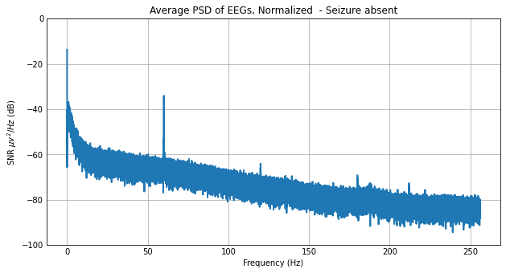

```python
plt.style.use('_mpl-gallery')
fig = plt.figure(figsize=(8, 4))
# plot
plt.plot(xf_abs[:N_abs//2], nonszData_uv_norm_ave_PSD[:N_abs//2], linewidth=2.0, label='nonseizure')
plt.grid(True)
plt.ylim((-100, 0))
plt.xlabel('Frequency (Hz)')
plt.ylabel('SNR ' r'$\mu v^{2}/Hz$' + ' (dB)')
plt.title('Average PSD of EEGs, Normalized ' + ' - Seizure absent')
```

Note the spike at 60 Hz, which is mostly likely from electrical components. One could use a notch filter to remove it.

```python
# Estimate the noise power. Use pre-ictal samples
sz_var = np.zeros((np.size(szData_uv,0)), dtype=float)
cnt = 0
for s in szIdx:
    # Normalization with pre-ictal samples
    #N = t_stop_sample[cnt] - t_start_sample[cnt] + 1
    #if int(t_start_sample[cnt] - N) < 0:
    #    nse_start_sample = 0
    #else:
    #    nse_start_sample = int(t_start_sample[cnt] - N)
    #nse = szData_uv[cnt][nse_start_sample : t_start_sample[cnt]] # Not inclusive of t_start_sample[cnt]

    # Normalization to unit variance of the seizure component itself
    nse = szData_uv[cnt][t_start_sample[cnt] : t_stop_sample[cnt]]
    sz_var[cnt] = np.var(nse)
    cnt += 1

# Normalize by the noise power
szData_uv_norm = np.zeros(np.shape(szData_uv), dtype=float)
cnt = 0
for s in szIdx:
    szData_uv_norm[cnt][:] = szData_uv[cnt][:] / np.sqrt(sz_var[cnt])
    # print(np.var(szData_uv_norm[cnt][t_start_sample[cnt] : t_stop_sample[cnt]]))
    cnt += 1
```

Compare the PSDs of seizure and non-seizure EEGs. Plot PSDs of normalized seizure EEGs over the average PSD of non-seizure EEG. Look for differences between the PSDs of seizure versus non-seizures.

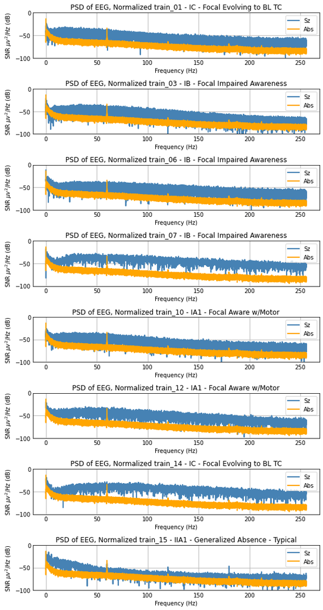

```python
plt.style.use('_mpl-gallery')
fig, ax = plt.subplots(np.size(szData_uv_norm,0),1,figsize=(8, 15))
cnt = 0
for s in szIdx:
    y = szData_uv_norm[cnt][t_start_sample[cnt]:t_stop_sample[cnt]]

    N = t_stop_sample[cnt] - t_start_sample[cnt] + 1
    f = fft(y)
    xf = fftfreq(N, T)
    # plot
    ax[cnt].plot(xf[:N//2], 20*np.log10(abs(f[:N//2])/N), color = 'steelblue',linewidth=2.0, label='Sz')
    ax[cnt].plot(xf_abs[:N_abs//2], nonszData_uv_norm_ave_PSD[:N_abs//2], color = 'orange', linewidth=2.0, label='Abs')
    ax[cnt].set_ylim((-100, 0))
    ax[cnt].grid(True)
    ax[cnt].legend(loc='upper right')
    ax[cnt].set_xlabel('Frequency (Hz)')
    ax[cnt].set_ylabel('SNR ' + r'$\mu v^{2}/Hz$' + ' (dB)')
    ax[cnt].set_title('PSD of EEG, Normalized ' + df['file_id'][s] + ' - ' + df['sz_type'][s])
    cnt += 1
fig.tight_layout()
plt.show()
```